**GitHub Repository:** https://github.com/sbains2/GSB544

# Activity 1.3 - Sahil Bains

# Data Visualization Using `plotnine`

The Palmer Penguins dataset had a variety of column types with which to explore some nice visualizations. The `mtcars` dataset is another popular dataset for doing some simple data work, but does not contain the same types of variables.

Run the following code to load the `mtcars` dataset and explore the observations and variables contained within. To learn more about this dataset check out [this site](https://stat.ethz.ch/R-manual/R-devel/library/datasets/html/mtcars.html)

```python
import statsmodels.api as sm
import pandas as pd
from plotnine import *

mtcars = pd.read_csv('mtcars.csv')
df = pd.DataFrame(mtcars)
```

The statement “the `mtcars` dataset does not contain the same types of variables as the penguins dataset” is a little true and a little false. There are no variables that contain text values, BUT there are variables that it makes sense to consider categorical variables. In most situations, it makes sense to treat the values of categorical variables as text values instead of numeric values.

Use the `astype()` method to convert the categorical variables of the `mtcars` (df) dataset to have text values in the code chunk below. We’ve done one for you!

```python
df.info()
```

```
<class 'pandas.core.frame.DataFrame'>
RangeIndex: 32 entries, 0 to 31
Data columns (total 12 columns):
 #   Column  Non-Null Count  Dtype
---  ------  --------------  -----
 0   model   32 non-null     object
 1   mpg     32 non-null     float64
 2   cyl     32 non-null     int64
 3   disp    32 non-null     float64
 4   hp      32 non-null     int64
 5   drat    32 non-null     float64
 6   wt      32 non-null     float64
 7   qsec    32 non-null     float64
 8   vs      32 non-null     int64
 9   am      32 non-null     int64
 10  gear    32 non-null     int64
 11  carb    32 non-null     int64
dtypes: float64(5), int64(6), object(1)
memory usage: 3.1+ KB
```

```python
df["am"] = df["am"].astype(str)

# Convert the other variables below
df["vs"] = df["vs"].astype(str)

df.info()
```

```
<class 'pandas.core.frame.DataFrame'>
RangeIndex: 32 entries, 0 to 31
Data columns (total 12 columns):
 #   Column  Non-Null Count  Dtype
---  ------  --------------  -----
 0   model   32 non-null     object
 1   mpg     32 non-null     float64
 2   cyl     32 non-null     int64
 3   disp    32 non-null     float64
 4   hp      32 non-null     int64
 5   drat    32 non-null     float64
 6   wt      32 non-null     float64
 7   qsec    32 non-null     float64
 8   vs      32 non-null     object
 9   am      32 non-null     object
 10  gear    32 non-null     int64
 11  carb    32 non-null     int64
dtypes: float64(5), int64(4), object(3)
memory usage: 3.1+ KB
```

If you print out your new dataset, is it clear that the variables have been converted to text values? If so, how can you tell?

It should also be clear by how `plotnine` treats these variables.

1. Create side-by-side boxplots of the `mpg` variable by the different values of the `am` variable. What happens if you convert the `am` variable back to float values and then try to create this same plot? Explain the differences between the two plots.
2. Create overlaid histograms of the `hp` variable for the different values of the `cyl` variable. What happens if you convert the `cyl` variable back to float values and then try to create this same plot? Explain the differences between the two plots.

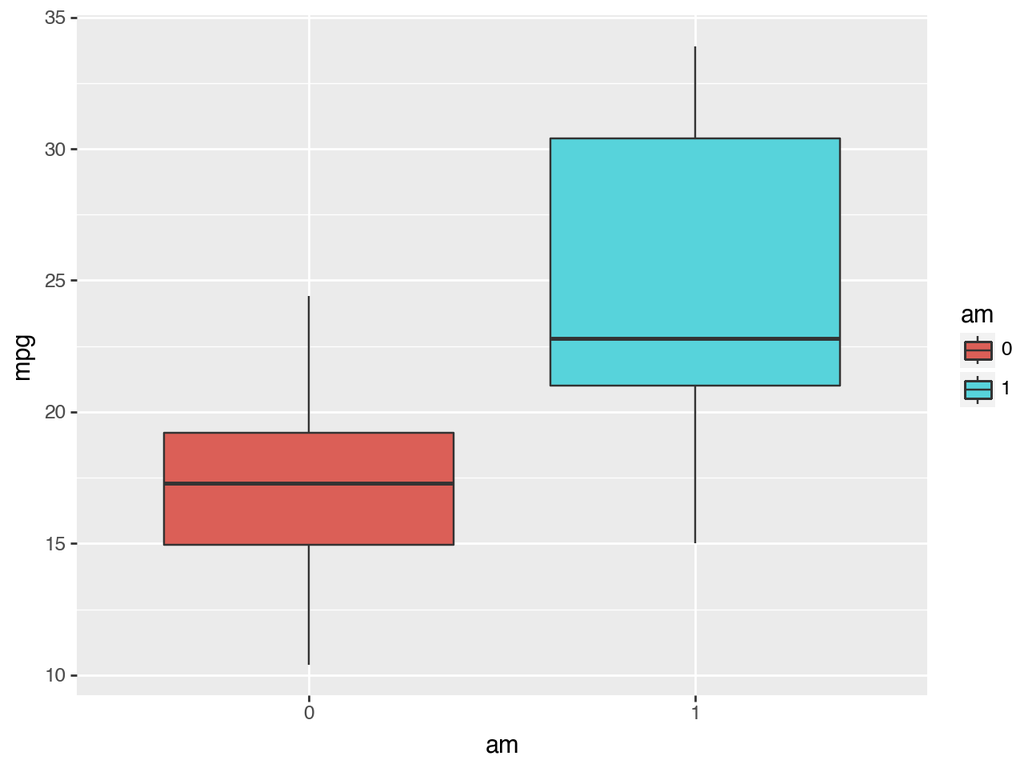

```python
# Create plot for (1) here
df["am"] = df["am"].astype(str)
(
  ggplot(df, aes(x='am', y='mpg', fill='am'))
  + geom_boxplot()

)
```

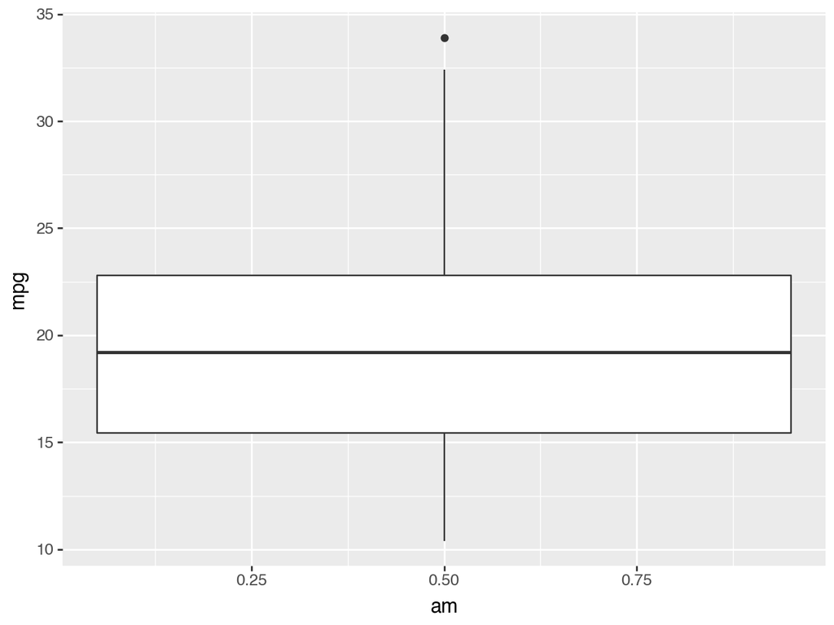

```python
df["am"] = df["am"].astype(float)
(
  ggplot(df, aes(x='am', y='mpg', fill='am'))
  + geom_boxplot()

)
```

Creating a side by side boxplot of am and mpg shows the fuel efficiency distribution for manual and automatic transmission vehicles. When am is stored as a categorical (str), the plot shows two distinct groups with a discrete x-axis. If am is converted into a float, the x-axis is treated as a continuous variable, the boxplot still appears but is less intuitive, as the categories aren’t distinguishable.

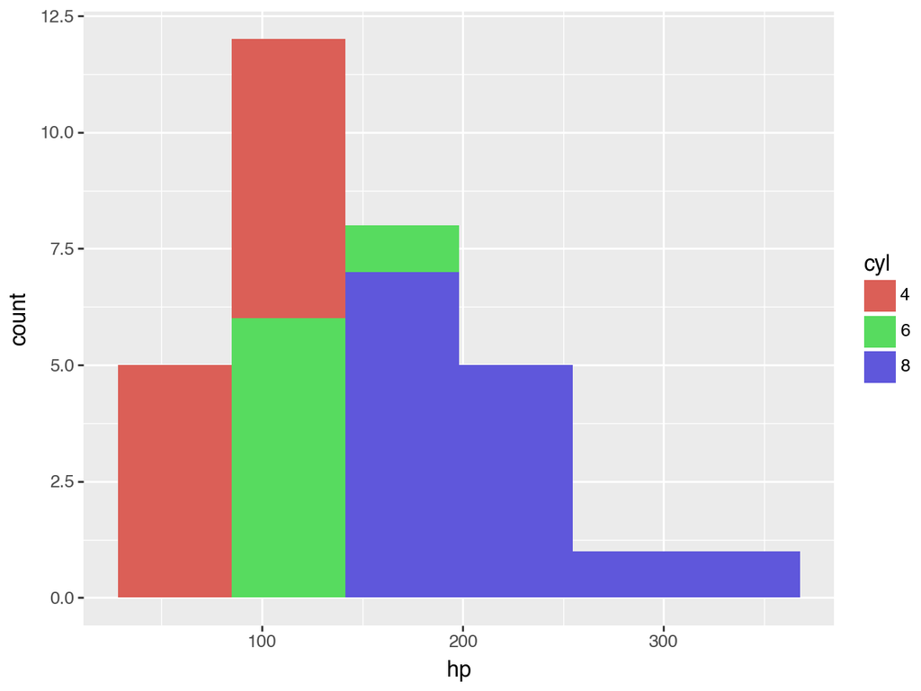

```python
# Create plot for (2) here
df["cyl"] = df["cyl"].astype(str)
(
  ggplot(df, aes('hp', fill='cyl'))
  + geom_histogram()
  + labs(x='hp', fill='cyl')

)
```

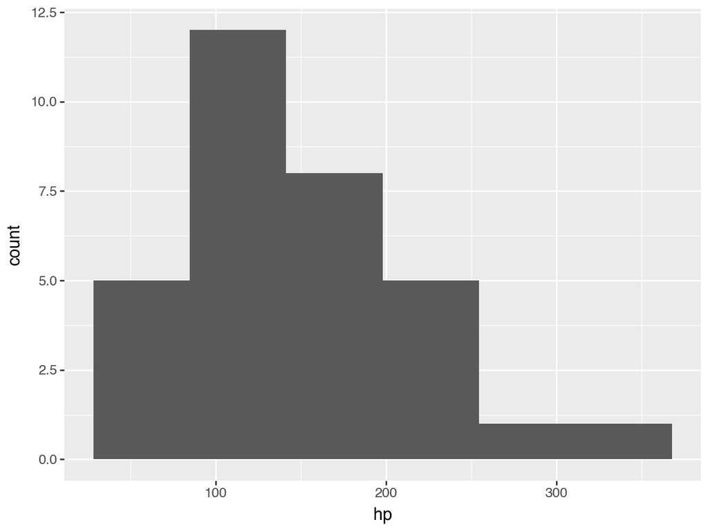

```python
df["cyl"] = df["cyl"].astype(float)
(
  ggplot(df, aes('hp', fill='cyl'))
  + geom_histogram()
  + labs(x='hp', fill='cyl')

)
```

Some of these variables, like the `cyl` variable, have numeric values that actually make sense as numbers (i.e. the number of cylinders in the engine). However, it doesn’t make the most sense to “do math” with this type of variable (e.g. take averages and such) because there are so few different value this can take on AND they’re an explicit choice made by the car manufacturer. So, it makes more sense to treat the `cyl` variable as a categorical variable despite it having numeric values.

You will need to keep these kinds of nuances about data in mind as you work with an increasing variety and richness of data, and do more complex things with them.

Choose 3 new `geometries` from the [data-to-viz website](https://www.data-to-viz.com/) for graphs that you’d like to explore using the `mtcars` dataset, and then create those graphs!

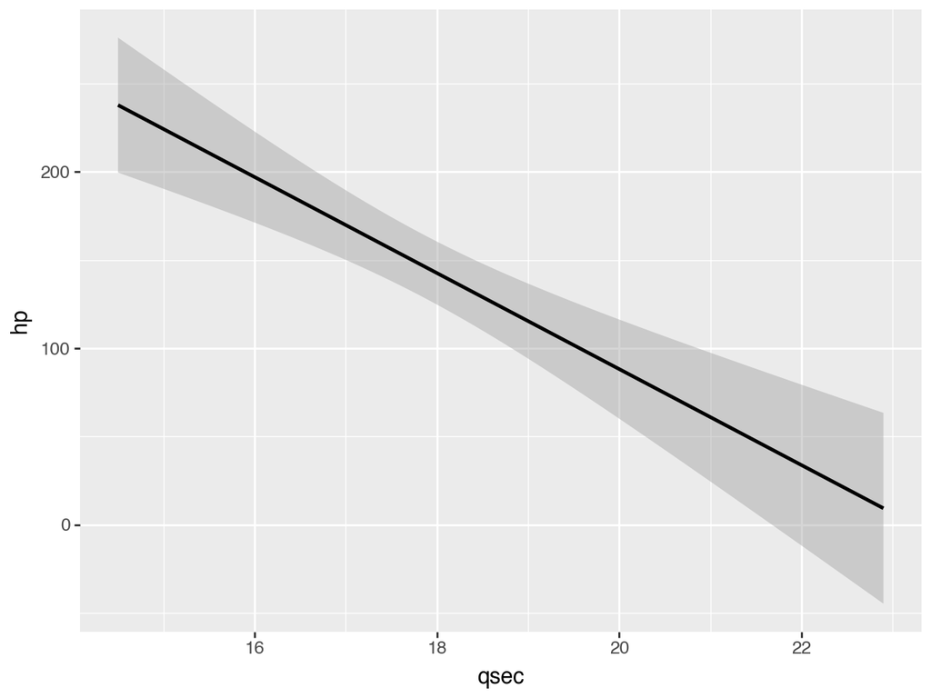

```python
(
  ggplot(df, aes(x='qsec',y='hp'))
  + geom_smooth(method='lm')
  + labs(x='qsec', fill='hp')

)
```

Here, I decided to measure the relationship with the quarter mile time and horsepower. There is a negative correlation that is visible between the longer quarter mile times, and decreasing horsepower.

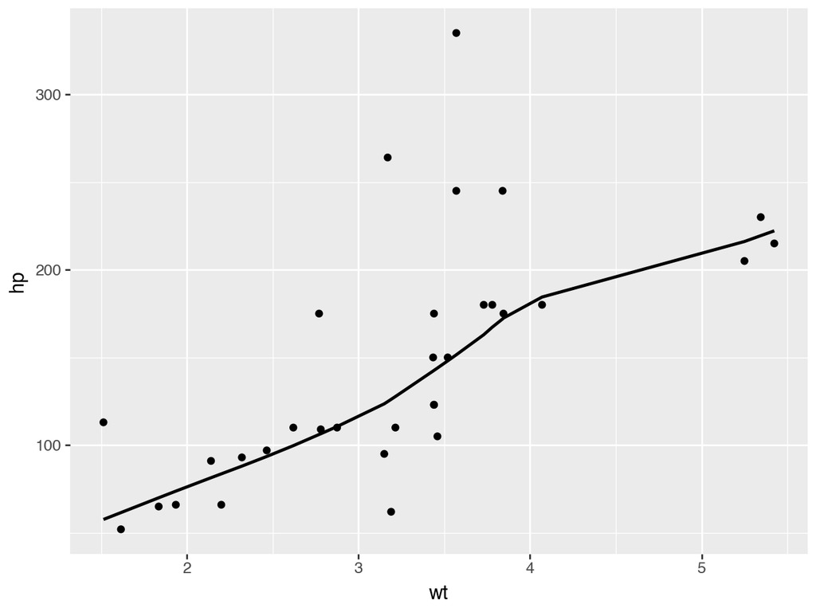

```python
# Create plot with second new geometry here
(
  ggplot(df, aes(x='wt',y='hp'))
  + geom_point()
  + geom_smooth()
  + labs(x='wt', fill='hp')

)
```

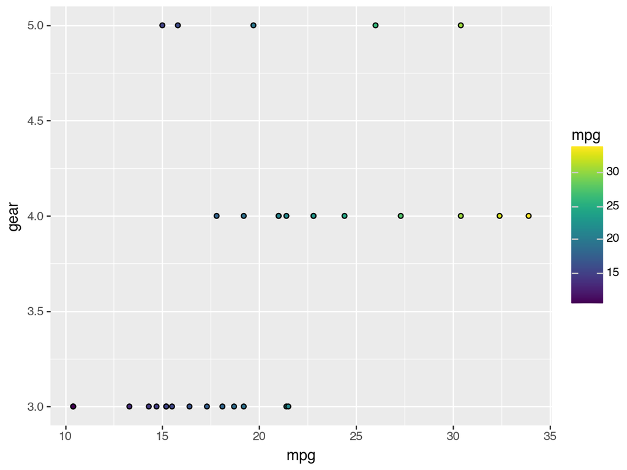

```python
# Create plot with third new geometry here
(
  ggplot(df, aes(x='mpg',y='gear', fill='mpg'))
  + geom_point()

)
```

Here, I was interested inthe relationship between efficiency and the type of gear. It seems that from the results, 4th gear is more favorable than most on average (estimated) in terms of best mileage.